# Project: Identify Customer Segments

In this project, you will apply unsupervised learning techniques to identify segments of the population that form the core customer base for a mail-order sales company in Germany. These segments can then be used to direct marketing campaigns towards audiences that will have the highest expected rate of returns. The data that you will use has been provided by our partners at Bertelsmann Arvato Analytics, and represents a real-life data science task.

This notebook will help you complete this task by providing a framework within which you will perform your analysis steps. In each step of the project, you will see some text describing the subtask that you will perform, followed by one or more code cells for you to complete your work. **Feel free to add additional code and markdown cells as you go along so that you can explore everything in precise chunks.** The code cells provided in the base template will outline only the major tasks, and will usually not be enough to cover all of the minor tasks that comprise it.

It should be noted that while there will be precise guidelines on how you should handle certain tasks in the project, there will also be places where an exact specification is not provided. **There will be times in the project where you will need to make and justify your own decisions on how to treat the data.** These are places where there may not be only one way to handle the data. In real-life tasks, there may be many valid ways to approach an analysis task. One of the most important things you can do is clearly document your approach so that other scientists can understand the decisions you've made.

At the end of most sections, there will be a Markdown cell labeled **Discussion**. In these cells, you will report your findings for the completed section, as well as document the decisions that you made in your approach to each subtask. **Your project will be evaluated not just on the code used to complete the tasks outlined, but also your communication about your observations and conclusions at each stage.**

```python
# import libraries here; add more as necessary
import numpy as np
import pandas as pd
import matplotlib.pyplot as plt
import seaborn as sns

# magic word for producing visualizations in notebook
%matplotlib inline
```

### Step 0: Load the Data

Each row of the demographics files represents a single person, but also includes information outside of individuals, including information about their household, building, and neighborhood. You will use this information to cluster the general population into groups with similar demographic properties. Then, you will see how the people in the customers dataset fit into those created clusters. The hope here is that certain clusters are over-represented in the customers data, as compared to the general population; those over-represented clusters will be assumed to be part of the core userbase. This information can then be used for further applications, such as targeting for a marketing campaign.

To start off with, load in the demographics data for the general population into a pandas DataFrame, and do the same for the feature attributes summary. Note for all of the `.csv` data files in this project: they're semicolon (`;`) delimited, so you'll need an additional argument in your [`read_csv()`](https://pandas.pydata.org/pandas-docs/stable/generated/pandas.read_csv.html) call to read in the data properly. Also, considering the size of the main dataset, it may take some time for it to load completely.

Once the dataset is loaded, it's recommended that you take a little bit of time just browsing the general structure of the dataset and feature summary file. You'll be getting deep into the innards of the cleaning in the first major step of the project, so gaining some general familiarity can help you get your bearings.

```python
# Load in the general demographics data.
azdias = pd.read_csv("Udacity_AZDIAS_Subset.csv", sep = ';')

# Load in the feature summary file.
feat_info = pd.read_csv("AZDIAS_Feature_Summary.csv", sep =';')
```

```python
# Check the structure of the data after it's loaded (e.g. print the number of
# rows and columns, print the first few rows).

print(np.shape(azdias))
print(np.shape(feat_info))
```

```
(891221, 85)
(85, 4)
```

```python
azdias.head(5)
```

|  | AGER_TYP | ALTERSKATEGORIE_GROB | ANREDE_KZ | CJT_GESAMTTYP | FINANZ_MINIMALIST | FINANZ_SPARER | FINANZ_VORSORGER | FINANZ_ANLEGER | FINANZ_UNAUFFAELLIGER | FINANZ_HAUSBAUER | ... | PLZ8_ANTG1 | PLZ8_ANTG2 | PLZ8_ANTG3 | PLZ8_ANTG4 | PLZ8_BAUMAX | PLZ8_HHZ | PLZ8_GBZ | ARBEIT | ORTSGR_KLS9 | RELAT_AB |
| --- | --- | --- | --- | --- | --- | --- | --- | --- | --- | --- | --- | --- | --- | --- | --- | --- | --- | --- | --- | --- | --- |
| 0 | -1 | 2 | 1 | 2.0 | 3 | 4 | 3 | 5 | 5 | 3 | ... | NaN | NaN | NaN | NaN | NaN | NaN | NaN | NaN | NaN | NaN |
| 1 | -1 | 1 | 2 | 5.0 | 1 | 5 | 2 | 5 | 4 | 5 | ... | 2.0 | 3.0 | 2.0 | 1.0 | 1.0 | 5.0 | 4.0 | 3.0 | 5.0 | 4.0 |
| 2 | -1 | 3 | 2 | 3.0 | 1 | 4 | 1 | 2 | 3 | 5 | ... | 3.0 | 3.0 | 1.0 | 0.0 | 1.0 | 4.0 | 4.0 | 3.0 | 5.0 | 2.0 |
| 3 | 2 | 4 | 2 | 2.0 | 4 | 2 | 5 | 2 | 1 | 2 | ... | 2.0 | 2.0 | 2.0 | 0.0 | 1.0 | 3.0 | 4.0 | 2.0 | 3.0 | 3.0 |
| 4 | -1 | 3 | 1 | 5.0 | 4 | 3 | 4 | 1 | 3 | 2 | ... | 2.0 | 4.0 | 2.0 | 1.0 | 2.0 | 3.0 | 3.0 | 4.0 | 6.0 | 5.0 |

5 rows × 85 columns

```python
feat_info.head(5)
```

|  | attribute | information_level | type | missing_or_unknown |
| --- | --- | --- | --- | --- |
| 0 | AGER_TYP | person | categorical | [-1,0] |
| 1 | ALTERSKATEGORIE_GROB | person | ordinal | [-1,0,9] |
| 2 | ANREDE_KZ | person | categorical | [-1,0] |
| 3 | CJT_GESAMTTYP | person | categorical | [0] |
| 4 | FINANZ_MINIMALIST | person | ordinal | [-1] |

```python
feat_info.info()
```

```
<class 'pandas.core.frame.DataFrame'>
RangeIndex: 85 entries, 0 to 84
Data columns (total 4 columns):
attribute             85 non-null object
information_level     85 non-null object
type                  85 non-null object
missing_or_unknown    85 non-null object
dtypes: object(4)
memory usage: 2.7+ KB
```

```python
azdias.info()
```

```
<class 'pandas.core.frame.DataFrame'>
RangeIndex: 891221 entries, 0 to 891220
Data columns (total 85 columns):
AGER_TYP                 891221 non-null int64
ALTERSKATEGORIE_GROB     891221 non-null int64
ANREDE_KZ                891221 non-null int64
CJT_GESAMTTYP            886367 non-null float64
FINANZ_MINIMALIST        891221 non-null int64
FINANZ_SPARER            891221 non-null int64
FINANZ_VORSORGER         891221 non-null int64
FINANZ_ANLEGER           891221 non-null int64
FINANZ_UNAUFFAELLIGER    891221 non-null int64
FINANZ_HAUSBAUER         891221 non-null int64
FINANZTYP                891221 non-null int64
GEBURTSJAHR              891221 non-null int64
GFK_URLAUBERTYP          886367 non-null float64
GREEN_AVANTGARDE         891221 non-null int64
HEALTH_TYP               891221 non-null int64
LP_LEBENSPHASE_FEIN      886367 non-null float64
LP_LEBENSPHASE_GROB      886367 non-null float64
LP_FAMILIE_FEIN          886367 non-null float64
LP_FAMILIE_GROB          886367 non-null float64
LP_STATUS_FEIN           886367 non-null float64
LP_STATUS_GROB           886367 non-null float64
NATIONALITAET_KZ         891221 non-null int64
PRAEGENDE_JUGENDJAHRE    891221 non-null int64
RETOURTYP_BK_S           886367 non-null float64
SEMIO_SOZ                891221 non-null int64
SEMIO_FAM                891221 non-null int64
SEMIO_REL                891221 non-null int64
SEMIO_MAT                891221 non-null int64
SEMIO_VERT               891221 non-null int64
SEMIO_LUST               891221 non-null int64
SEMIO_ERL                891221 non-null int64
SEMIO_KULT               891221 non-null int64
SEMIO_RAT                891221 non-null int64
SEMIO_KRIT               891221 non-null int64
SEMIO_DOM                891221 non-null int64
SEMIO_KAEM               891221 non-null int64
SEMIO_PFLICHT            891221 non-null int64
```

[output cut: 35 more lines]

```
ONLINE_AFFINITAET        886367 non-null float64
REGIOTYP                 770025 non-null float64
KBA13_ANZAHL_PKW         785421 non-null float64
PLZ8_ANTG1               774706 non-null float64
PLZ8_ANTG2               774706 non-null float64
PLZ8_ANTG3               774706 non-null float64
PLZ8_ANTG4               774706 non-null float64
PLZ8_BAUMAX              774706 non-null float64
PLZ8_HHZ                 774706 non-null float64
PLZ8_GBZ                 774706 non-null float64
ARBEIT                   794005 non-null float64
ORTSGR_KLS9              794005 non-null float64
RELAT_AB                 794005 non-null float64
dtypes: float64(49), int64(32), object(4)
memory usage: 578.0+ MB
```

> **Tip**: Add additional cells to keep everything in reasonably-sized chunks! Keyboard shortcut `esc --> a` (press escape to enter command mode, then press the 'A' key) adds a new cell before the active cell, and `esc --> b` adds a new cell after the active cell. If you need to convert an active cell to a markdown cell, use `esc --> m` and to convert to a code cell, use `esc --> y`.

## Step 1: Preprocessing

### Step 1.1: Assess Missing Data

The feature summary file contains a summary of properties for each demographics data column. You will use this file to help you make cleaning decisions during this stage of the project. First of all, you should assess the demographics data in terms of missing data. Pay attention to the following points as you perform your analysis, and take notes on what you observe. Make sure that you fill in the **Discussion** cell with your findings and decisions at the end of each step that has one!

#### Step 1.1.1: Convert Missing Value Codes to NaNs

The fourth column of the feature attributes summary (loaded in above as `feat_info`) documents the codes from the data dictionary that indicate missing or unknown data. While the file encodes this as a list (e.g. `[-1,0]`), this will get read in as a string object. You'll need to do a little bit of parsing to make use of it to identify and clean the data. Convert data that matches a 'missing' or 'unknown' value code into a numpy NaN value. You might want to see how much data takes on a 'missing' or 'unknown' code, and how much data is naturally missing, as a point of interest.

**As one more reminder, you are encouraged to add additional cells to break up your analysis into manageable chunks.**

```python
# Identify missing or unknown data values and convert them to NaNs.

missing_values = []
for i in range(feat_info.shape[0]):
    attribute = feat_info["attribute"][i]
    sth = [value for value in feat_info["missing_or_unknown"][i].\
                                   replace("[","").replace("]","").split(",")]
    if 'XX' in sth:
        missing_values.append(sth)
    elif 'X' in sth:
        missing_values.append(sth)
    elif sth=='':
        missing_values.append(np.nan)
    else:
        missing_values.append(pd.to_numeric(sth))

feat_info['missing_or_unknown'] = missing_values

feat_info['missing_or_unknown'][57] = [-1, 'X']
feat_info['missing_or_unknown'][59] = [-1, 'XX']
```

#### Lets calculate the missing encoded data points by finding the number of missing data points before and after the conversion

We can calculate the number of encoded missing data points by finding the difference between total missing missing data points and actually missing data points.

```python
actual_missing_values = azdias.isnull().sum().sum()
print("The number of actual missing data points is ", actual_missing_values)
```

```
The number of actual missing data points is  4896838
```

```python
#Replace values in dataset
for i in range(feat_info.shape[0]):
    attribute = feat_info["attribute"][i]
    azdias[attribute] = azdias[attribute].replace(feat_info["missing_or_unknown"][i], np.nan)
```

```python
total_missing_values_after_replacing = azdias.isnull().sum().sum()
print("The number of total missing data points is ", total_missing_values_after_replacing)
```

```
The number of total missing data points is  8373929
```

```python
encoded_missing_values = total_missing_values_after_replacing - actual_missing_values
print("There were {} encoded missing values in the dataset, which represents {}% of the total number of missing values in the dataset"
      .format(encoded_missing_values, round(encoded_missing_values/total_missing_values_after_replacing *100, 2)))
```

```
There were 3477091 encoded missing values in the dataset, which represents 41.52% of the total number of missing values in the dataset
```

#### Step 1.1.2: Assess Missing Data in Each Column

How much missing data is present in each column? There are a few columns that are outliers in terms of the proportion of values that are missing. You will want to use matplotlib's [`hist()`](https://matplotlib.org/api/_as_gen/matplotlib.pyplot.hist.html) function to visualize the distribution of missing value counts to find these columns. Identify and document these columns. While some of these columns might have justifications for keeping or re-encoding the data, for this project you should just remove them from the dataframe. (Feel free to make remarks about these outlier columns in the discussion, however!)

For the remaining features, are there any patterns in which columns have, or share, missing data?

```python
# Perform an assessment of how much missing data there is in each column of the
# dataset.

n_missing_column_data = azdias.isnull().sum(axis=0)
n_missing_column_data
print (np.shape(n_missing_column_data))
```

```
(85,)
```

```python
# Percentage of missing data
prop_missing_column_data = (n_missing_column_data/azdias.shape[0])*100

print(prop_missing_column_data.head(10))
print(np.shape(prop_missing_column_data))
```

```
AGER_TYP                 76.955435
ALTERSKATEGORIE_GROB      0.323264
ANREDE_KZ                 0.000000
CJT_GESAMTTYP             0.544646
FINANZ_MINIMALIST         0.000000
FINANZ_SPARER             0.000000
FINANZ_VORSORGER          0.000000
FINANZ_ANLEGER            0.000000
FINANZ_UNAUFFAELLIGER     0.000000
FINANZ_HAUSBAUER          0.000000
dtype: float64
(85,)
```

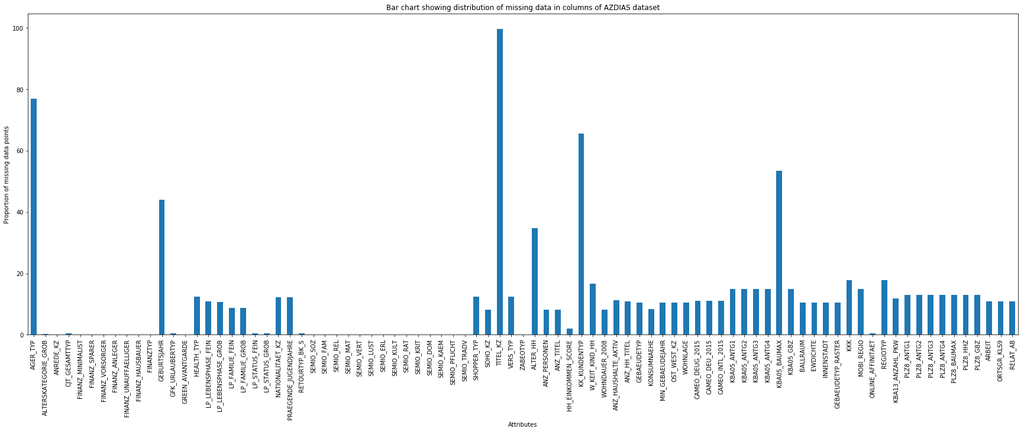

```python
# Investigate patterns in the amount of missing data in each column.
fig = plt.figure(figsize=(30,10))
ax = prop_missing_column_data.plot.bar()
ax.set_title("Bar chart showing distribution of missing data in columns of AZDIAS dataset")
ax.set_xlabel("Attributes")
ax.set_ylabel("Proportion of missing data points")
plt.show()
```

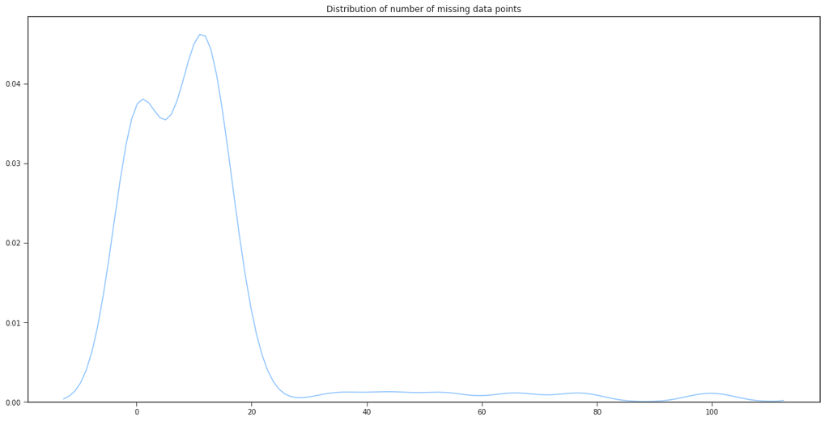

```python
sns.set_style("ticks")
sns.set_palette("pastel")
fig = plt.figure(figsize=(20,10))
ax = sns.kdeplot(prop_missing_column_data)
ax.set_title("Distribution of number of missing data points")
plt.show()
```

```python
# Any column with more than 20% missing data will be eliminated

columns_to_drop = list(n_missing_column_data[prop_missing_column_data >=20.0].index.values)
columns_to_drop
```

```
['AGER_TYP',
 'GEBURTSJAHR',
 'TITEL_KZ',
 'ALTER_HH',
 'KK_KUNDENTYP',
 'KBA05_BAUMAX']
```

```python
azdias.drop(columns_to_drop, axis=1, inplace=True)
```

```python
azdias.info()
```

```
<class 'pandas.core.frame.DataFrame'>
RangeIndex: 891221 entries, 0 to 891220
Data columns (total 79 columns):
ALTERSKATEGORIE_GROB     888340 non-null float64
ANREDE_KZ                891221 non-null int64
CJT_GESAMTTYP            886367 non-null float64
FINANZ_MINIMALIST        891221 non-null int64
FINANZ_SPARER            891221 non-null int64
FINANZ_VORSORGER         891221 non-null int64
FINANZ_ANLEGER           891221 non-null int64
FINANZ_UNAUFFAELLIGER    891221 non-null int64
FINANZ_HAUSBAUER         891221 non-null int64
FINANZTYP                891221 non-null int64
GFK_URLAUBERTYP          886367 non-null float64
GREEN_AVANTGARDE         891221 non-null int64
HEALTH_TYP               780025 non-null float64
LP_LEBENSPHASE_FEIN      793589 non-null float64
LP_LEBENSPHASE_GROB      796649 non-null float64
LP_FAMILIE_FEIN          813429 non-null float64
LP_FAMILIE_GROB          813429 non-null float64
LP_STATUS_FEIN           886367 non-null float64
LP_STATUS_GROB           886367 non-null float64
NATIONALITAET_KZ         782906 non-null float64
PRAEGENDE_JUGENDJAHRE    783057 non-null float64
RETOURTYP_BK_S           886367 non-null float64
SEMIO_SOZ                891221 non-null int64
SEMIO_FAM                891221 non-null int64
SEMIO_REL                891221 non-null int64
SEMIO_MAT                891221 non-null int64
SEMIO_VERT               891221 non-null int64
SEMIO_LUST               891221 non-null int64
SEMIO_ERL                891221 non-null int64
SEMIO_KULT               891221 non-null int64
SEMIO_RAT                891221 non-null int64
SEMIO_KRIT               891221 non-null int64
SEMIO_DOM                891221 non-null int64
SEMIO_KAEM               891221 non-null int64
SEMIO_PFLICHT            891221 non-null int64
SEMIO_TRADV              891221 non-null int64
SHOPPER_TYP              780025 non-null float64
```

[output cut: 29 more lines]

```
ONLINE_AFFINITAET        886367 non-null float64
REGIOTYP                 733157 non-null float64
KBA13_ANZAHL_PKW         785421 non-null float64
PLZ8_ANTG1               774706 non-null float64
PLZ8_ANTG2               774706 non-null float64
PLZ8_ANTG3               774706 non-null float64
PLZ8_ANTG4               774706 non-null float64
PLZ8_BAUMAX              774706 non-null float64
PLZ8_HHZ                 774706 non-null float64
PLZ8_GBZ                 774706 non-null float64
ARBEIT                   793846 non-null float64
ORTSGR_KLS9              793947 non-null float64
RELAT_AB                 793846 non-null float64
dtypes: float64(51), int64(24), object(4)
memory usage: 537.2+ MB
```

#### Discussion 1.1.2: Assess Missing Data in Each Column

Any column with more than 20% missing data was eliminated. The columns with lots of missing data were those of individual records, like people's titles, dates of birth, ageing, etc.

I removed six columns from the data: 'AGER_TYP', 'GEBURTSJAHR', 'TITEL_KZ', 'ALTER_HH', 'KK_KUNDENTYP', and 'KBA05_BAUMAX'.

#### Step 1.1.3: Assess Missing Data in Each Row

Now, you'll perform a similar assessment for the rows of the dataset. How much data is missing in each row? As with the columns, you should see some groups of points that have a very different numbers of missing values. Divide the data into two subsets: one for data points that are above some threshold for missing values, and a second subset for points below that threshold.

In order to know what to do with the outlier rows, we should see if the distribution of data values on columns that are not missing data (or are missing very little data) are similar or different between the two groups. Select at least five of these columns and compare the distribution of values.

- You can use seaborn's [`countplot()`](https://seaborn.pydata.org/generated/seaborn.countplot.html) function to create a bar chart of code frequencies and matplotlib's [`subplot()`](https://matplotlib.org/api/_as_gen/matplotlib.pyplot.subplot.html) function to put bar charts for the two subplots side by side.
- To reduce repeated code, you might want to write a function that can perform this comparison, taking as one of its arguments a column to be compared.

Depending on what you observe in your comparison, this will have implications on how you approach your conclusions later in the analysis. If the distributions of non-missing features look similar between the data with many missing values and the data with few or no missing values, then we could argue that simply dropping those points from the analysis won't present a major issue. On the other hand, if the data with many missing values looks very different from the data with few or no missing values, then we should make a note on those data as special. We'll revisit these data later on. **Either way, you should continue your analysis for now using just the subset of the data with few or no missing values.**

```python
# How much data is missing in each row of the dataset?
missing_row_data = azdias.isnull().sum(axis=1)

# what does that mean in terms of proportions?
prop_missing_row_data = (missing_row_data/azdias.shape[1])*100
```

```python
prop_missing_row_data
```

```
0         54.430380
1          0.000000
2          0.000000
3          8.860759
4          0.000000
5          0.000000
6          0.000000
7          0.000000
8          0.000000
9          0.000000
10         0.000000
11        59.493671
12         7.594937
13        10.126582
14        59.493671
```

[output cut: 47 more lines]

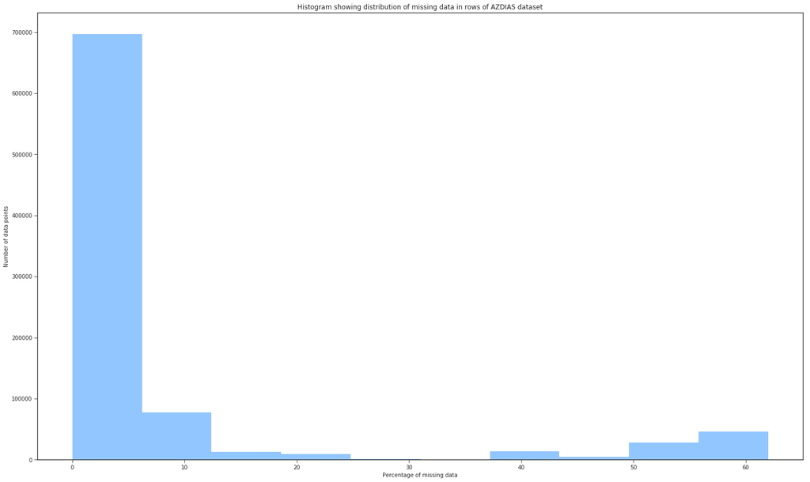

```python
# Investigate patterns in the amount of missing data in each row.
fig = plt.figure(figsize=(25,15))
sns.set_style("ticks")
ax = prop_missing_row_data.plot.hist()
ax.set_title("Histogram showing distribution of missing data in rows of AZDIAS dataset")
ax.set_xlabel("Percentage of missing data")
ax.set_ylabel("Number of data points")
plt.show()
```

```python
# Write code to divide the data into two subsets based on the number of missing
# values in each row.

rows_without_missing_values = list(np.where(missing_row_data <=0)[0])
rows_with_missing_values = list(np.where(missing_row_data >0)[0])

azdias_few_missing_values = azdias.loc[rows_without_missing_values, :]
azdias_many_missing_values = azdias.loc[rows_with_missing_values, :]
```

```python
azdias_few_missing_values.info()
```

```
<class 'pandas.core.frame.DataFrame'>
Int64Index: 623209 entries, 1 to 891220
Data columns (total 79 columns):
ALTERSKATEGORIE_GROB     623209 non-null float64
ANREDE_KZ                623209 non-null int64
CJT_GESAMTTYP            623209 non-null float64
FINANZ_MINIMALIST        623209 non-null int64
FINANZ_SPARER            623209 non-null int64
FINANZ_VORSORGER         623209 non-null int64
FINANZ_ANLEGER           623209 non-null int64
FINANZ_UNAUFFAELLIGER    623209 non-null int64
FINANZ_HAUSBAUER         623209 non-null int64
FINANZTYP                623209 non-null int64
GFK_URLAUBERTYP          623209 non-null float64
GREEN_AVANTGARDE         623209 non-null int64
HEALTH_TYP               623209 non-null float64
LP_LEBENSPHASE_FEIN      623209 non-null float64
LP_LEBENSPHASE_GROB      623209 non-null float64
LP_FAMILIE_FEIN          623209 non-null float64
LP_FAMILIE_GROB          623209 non-null float64
LP_STATUS_FEIN           623209 non-null float64
LP_STATUS_GROB           623209 non-null float64
NATIONALITAET_KZ         623209 non-null float64
PRAEGENDE_JUGENDJAHRE    623209 non-null float64
RETOURTYP_BK_S           623209 non-null float64
SEMIO_SOZ                623209 non-null int64
SEMIO_FAM                623209 non-null int64
SEMIO_REL                623209 non-null int64
SEMIO_MAT                623209 non-null int64
SEMIO_VERT               623209 non-null int64
SEMIO_LUST               623209 non-null int64
SEMIO_ERL                623209 non-null int64
SEMIO_KULT               623209 non-null int64
SEMIO_RAT                623209 non-null int64
SEMIO_KRIT               623209 non-null int64
SEMIO_DOM                623209 non-null int64
SEMIO_KAEM               623209 non-null int64
SEMIO_PFLICHT            623209 non-null int64
SEMIO_TRADV              623209 non-null int64
SHOPPER_TYP              623209 non-null float64
```

[output cut: 29 more lines]

```
ONLINE_AFFINITAET        623209 non-null float64
REGIOTYP                 623209 non-null float64
KBA13_ANZAHL_PKW         623209 non-null float64
PLZ8_ANTG1               623209 non-null float64
PLZ8_ANTG2               623209 non-null float64
PLZ8_ANTG3               623209 non-null float64
PLZ8_ANTG4               623209 non-null float64
PLZ8_BAUMAX              623209 non-null float64
PLZ8_HHZ                 623209 non-null float64
PLZ8_GBZ                 623209 non-null float64
ARBEIT                   623209 non-null float64
ORTSGR_KLS9              623209 non-null float64
RELAT_AB                 623209 non-null float64
dtypes: float64(51), int64(24), object(4)
memory usage: 380.4+ MB
```

```python
azdias_many_missing_values.info()
```

```
<class 'pandas.core.frame.DataFrame'>
Int64Index: 268012 entries, 0 to 891218
Data columns (total 79 columns):
ALTERSKATEGORIE_GROB     265131 non-null float64
ANREDE_KZ                268012 non-null int64
CJT_GESAMTTYP            263158 non-null float64
FINANZ_MINIMALIST        268012 non-null int64
FINANZ_SPARER            268012 non-null int64
FINANZ_VORSORGER         268012 non-null int64
FINANZ_ANLEGER           268012 non-null int64
FINANZ_UNAUFFAELLIGER    268012 non-null int64
FINANZ_HAUSBAUER         268012 non-null int64
FINANZTYP                268012 non-null int64
GFK_URLAUBERTYP          263158 non-null float64
GREEN_AVANTGARDE         268012 non-null int64
HEALTH_TYP               156816 non-null float64
LP_LEBENSPHASE_FEIN      170380 non-null float64
LP_LEBENSPHASE_GROB      173440 non-null float64
LP_FAMILIE_FEIN          190220 non-null float64
LP_FAMILIE_GROB          190220 non-null float64
LP_STATUS_FEIN           263158 non-null float64
LP_STATUS_GROB           263158 non-null float64
NATIONALITAET_KZ         159697 non-null float64
PRAEGENDE_JUGENDJAHRE    159848 non-null float64
RETOURTYP_BK_S           263158 non-null float64
SEMIO_SOZ                268012 non-null int64
SEMIO_FAM                268012 non-null int64
SEMIO_REL                268012 non-null int64
SEMIO_MAT                268012 non-null int64
SEMIO_VERT               268012 non-null int64
SEMIO_LUST               268012 non-null int64
SEMIO_ERL                268012 non-null int64
SEMIO_KULT               268012 non-null int64
SEMIO_RAT                268012 non-null int64
SEMIO_KRIT               268012 non-null int64
SEMIO_DOM                268012 non-null int64
SEMIO_KAEM               268012 non-null int64
SEMIO_PFLICHT            268012 non-null int64
SEMIO_TRADV              268012 non-null int64
SHOPPER_TYP              156816 non-null float64
```

[output cut: 29 more lines]

```
ONLINE_AFFINITAET        263158 non-null float64
REGIOTYP                 109948 non-null float64
KBA13_ANZAHL_PKW         162212 non-null float64
PLZ8_ANTG1               151497 non-null float64
PLZ8_ANTG2               151497 non-null float64
PLZ8_ANTG3               151497 non-null float64
PLZ8_ANTG4               151497 non-null float64
PLZ8_BAUMAX              151497 non-null float64
PLZ8_HHZ                 151497 non-null float64
PLZ8_GBZ                 151497 non-null float64
ARBEIT                   170637 non-null float64
ORTSGR_KLS9              170738 non-null float64
RELAT_AB                 170637 non-null float64
dtypes: float64(51), int64(24), object(4)
memory usage: 163.6+ MB
```

```python
# Compare the distribution of values for at least five columns where there are
# no or few missing values, between the two subsets.

def compare_distribution(column_name):
    fig = plt.figure(figsize=(10,5))
    fig.suptitle("Comparison of dataset with missing values and dataset without missing values")

    #fig.subplots(nrows=2, ncols=2, sharex='col', sharey='row')
    plt.subplot(1,2,1)

    ax1 = sns.countplot(data = azdias_few_missing_values, x=azdias_few_missing_values[column_name])
    ax1.set_xlabel("Value")
    ax1.set_ylabel("Count")
    ax1.set_title("Dataset without missing values")
    plt.subplot(1,2,2)
    ax2 = sns.countplot(data=azdias_many_missing_values, x=azdias_many_missing_values[column_name])
    ax2.set_title("Dataset with some missing values")
    ax2.set_xlabel("Value")
    ax2.set_ylabel("Count")

    fig.tight_layout()
    fig.subplots_adjust(top=0.88, wspace=0.4)
    plt.show()
```

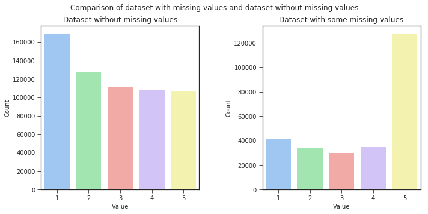

```python
compare_distribution('FINANZ_ANLEGER')
```

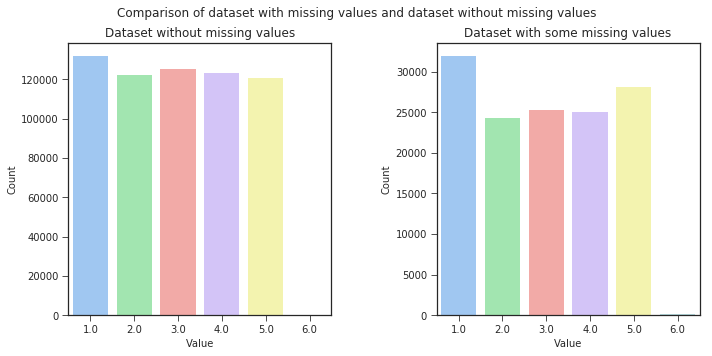

```python
compare_distribution('MOBI_REGIO')
```

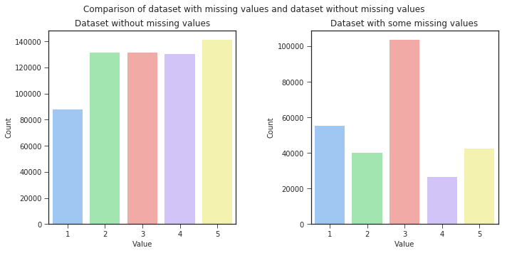

```python
compare_distribution('FINANZ_HAUSBAUER')
```

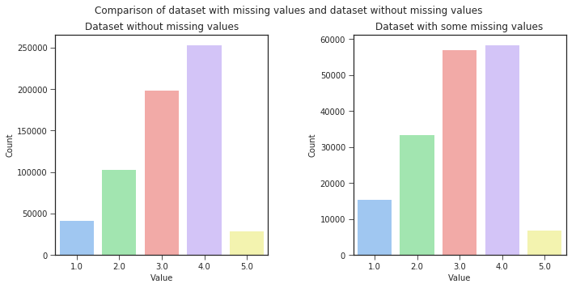

```python
compare_distribution('ARBEIT')
```

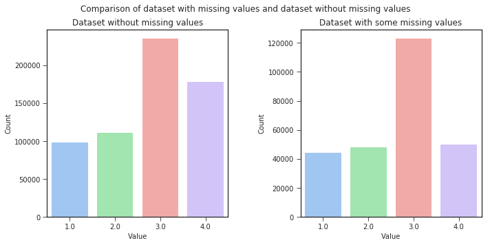

```python
compare_distribution('ALTERSKATEGORIE_GROB')
```

### Step 1.2: Select and Re-Encode Features

Checking for missing data isn't the only way in which you can prepare a dataset for analysis. Since the unsupervised learning techniques to be used will only work on data that is encoded numerically, you need to make a few encoding changes or additional assumptions to be able to make progress. In addition, while almost all of the values in the dataset are encoded using numbers, not all of them represent numeric values. Check the third column of the feature summary (`feat_info`) for a summary of types of measurement.

- For numeric and interval data, these features can be kept without changes.
- Most of the variables in the dataset are ordinal in nature. While ordinal values may technically be non-linear in spacing, make the simplifying assumption that the ordinal variables can be treated as being interval in nature (that is, kept without any changes).
- Special handling may be necessary for the remaining two variable types: categorical, and 'mixed'.

In the first two parts of this sub-step, you will perform an investigation of the categorical and mixed-type features and make a decision on each of them, whether you will keep, drop, or re-encode each. Then, in the last part, you will create a new data frame with only the selected and engineered columns.

Data wrangling is often the trickiest part of the data analysis process, and there's a lot of it to be done here. But stick with it: once you're done with this step, you'll be ready to get to the machine learning parts of the project!

```python
# How many features are there of each data type?

for mm in feat_info["type"].unique():
    print("There are {} {} features".format(feat_info[feat_info["type"]==mm].shape[0],mm))
```

```
There are 21 categorical features
There are 49 ordinal features
There are 7 numeric features
There are 7 mixed features
There are 1 interval features
```

#### Step 1.2.1: Re-Encode Categorical Features

For categorical data, you would ordinarily need to encode the levels as dummy variables. Depending on the number of categories, perform one of the following:

- For binary (two-level) categoricals that take numeric values, you can keep them without needing to do anything.
- There is one binary variable that takes on non-numeric values. For this one, you need to re-encode the values as numbers or create a dummy variable.
- For multi-level categoricals (three or more values), you can choose to encode the values using multiple dummy variables (e.g. via [OneHotEncoder](http://scikit-learn.org/stable/modules/generated/sklearn.preprocessing.OneHotEncoder.html)), or (to keep things straightforward) just drop them from the analysis. As always, document your choices in the Discussion section.

```python
# Assess categorical variables: which are binary, which are multi-level, and
# which one needs to be re-encoded?


### BINARY ####

categorical_features = feat_info[feat_info["type"]=="categorical"]["attribute"]

display(categorical_features)
```

```
0             AGER_TYP
2            ANREDE_KZ
3        CJT_GESAMTTYP
10           FINANZTYP
12     GFK_URLAUBERTYP
13    GREEN_AVANTGARDE
17     LP_FAMILIE_FEIN
18     LP_FAMILIE_GROB
19      LP_STATUS_FEIN
20      LP_STATUS_GROB
21    NATIONALITAET_KZ
38         SHOPPER_TYP
39             SOHO_KZ
40            TITEL_KZ
41            VERS_TYP
42            ZABEOTYP
47        KK_KUNDENTYP
52         GEBAEUDETYP
55         OST_WEST_KZ
57     CAMEO_DEUG_2015
58      CAMEO_DEU_2015
Name: attribute, dtype: object
```

```python
azdias = azdias_few_missing_values
```

```python
cat_features = pd.DataFrame()
features = []
n_categories = []
for feature in categorical_features:
    if feature in list(azdias):
        features.append(feature)
        n_categories.append(len(azdias[feature].unique()))
    else:
        pass

cat_features['features'] = features
cat_features['n_categories'] = n_categories
display(cat_features[cat_features.n_categories==2])
```

|  | features | n_categories |
| --- | --- | --- |
| 0 | ANREDE_KZ | 2 |
| 4 | GREEN_AVANTGARDE | 2 |
| 11 | SOHO_KZ | 2 |
| 12 | VERS_TYP | 2 |
| 15 | OST_WEST_KZ | 2 |

```python
# Re-encode categorical variable(s) to be kept in the analysis.

new_values = {'W': 1, 'O': 0}
azdias.replace({'OST_WEST_KZ':{'W': 1, 'O': 0}}, inplace=True)
```

#### Discussion 1.2.1: Re-Encode Categorical Features

We see from the cell above that the following are binary features:

- ANREDE_KZ
- GREEN_AVANTGARDE
- SOHO_KZ
- VERS_TYP
- OST_WEST_KZ

OST_WEST_KZ is binary, but needs to be re-encoded, since it takes on non-numeric values ('W' and 'O').

```python
# Assess categorical variables which are multi-level :

### MULTI LEVEL ###

display(cat_features[cat_features.n_categories>2])
```

|  | features | n_categories |
| --- | --- | --- |
| 1 | CJT_GESAMTTYP | 6 |
| 2 | FINANZTYP | 6 |
| 3 | GFK_URLAUBERTYP | 12 |
| 5 | LP_FAMILIE_FEIN | 11 |
| 6 | LP_FAMILIE_GROB | 5 |
| 7 | LP_STATUS_FEIN | 10 |
| 8 | LP_STATUS_GROB | 5 |
| 9 | NATIONALITAET_KZ | 3 |
| 10 | SHOPPER_TYP | 4 |
| 13 | ZABEOTYP | 6 |
| 14 | GEBAEUDETYP | 4 |
| 16 | CAMEO_DEUG_2015 | 9 |
| 17 | CAMEO_DEU_2015 | 44 |

From looking at the description of the remaining categorical features in the dataset, I came to the following conclusions:

- 'CACAMEO_DEUG_2015' and 'CAMEO_DEU_2015' both describe the wealth and life stage typology, albeit at different scales. I will keep 'CAMEO_DEUG_2015', that which describes the typology at the rough scale.
- The same is true of 'LP_FAMILIE_FEIN' and 'LP_FAMILIE_GROB' and 'LP_STATUS_FEIN' and 'LP_STATUS_GROB'.
- I also drop 'GEBAEUDETYP'

As a result, I will drop the following columns: 'GEBAEUDETYP', 'CAMEO_DEU_2015', 'LP_STATUS_FEIN' and 'LP_FAMILLE_FEIN'.

And one-hot-encode the remaining variables.

```python
cat_columns_to_drop =['CAMEO_DEU_2015','LP_STATUS_FEIN','LP_FAMILIE_FEIN', 'GEBAEUDETYP']
```

```python
azdias = pd.get_dummies(azdias, columns=['NATIONALITAET_KZ', 'CJT_GESAMTTYP', 'FINANZTYP', 'GFK_URLAUBERTYP', 'LP_FAMILIE_GROB', 'LP_STATUS_GROB',
                               'SHOPPER_TYP', 'ZABEOTYP', 'CAMEO_DEUG_2015']);
```

```python
azdias.info()
```

```
<class 'pandas.core.frame.DataFrame'>
Int64Index: 623209 entries, 1 to 891220
Columns: 126 entries, ALTERSKATEGORIE_GROB to CAMEO_DEUG_2015_9
dtypes: float64(45), int64(23), object(2), uint8(56)
memory usage: 390.9+ MB
```

#### Step 1.2.2: Engineer Mixed-Type Features

There are a handful of features that are marked as "mixed" in the feature summary that require special treatment in order to be included in the analysis. There are two in particular that deserve attention; the handling of the rest are up to your own choices:

- "PRAEGENDE_JUGENDJAHRE" combines information on three dimensions: generation by decade, movement (mainstream vs. avantgarde), and nation (east vs. west). While there aren't enough levels to disentangle east from west, you should create two new variables to capture the other two dimensions: an interval-type variable for decade, and a binary variable for movement.
- "CAMEO_INTL_2015" combines information on two axes: wealth and life stage. Break up the two-digit codes by their 'tens'-place and 'ones'-place digits into two new ordinal variables (which, for the purposes of this project, is equivalent to just treating them as their raw numeric values).
- If you decide to keep or engineer new features around the other mixed-type features, make sure you note your steps in the Discussion section.

Be sure to check `Data_Dictionary.md` for the details needed to finish these tasks.

```python
mixed_features = feat_info[feat_info["type"]=="mixed"]["attribute"]

for feature in mixed_features:
    if feature in list(azdias):
        print(feature)
    else:
        pass
```

```
LP_LEBENSPHASE_FEIN
LP_LEBENSPHASE_GROB
PRAEGENDE_JUGENDJAHRE
WOHNLAGE
CAMEO_INTL_2015
PLZ8_BAUMAX
```

```python
# Investigate "PRAEGENDE_JUGENDJAHRE" and engineer two new variables.
display(azdias['PRAEGENDE_JUGENDJAHRE'])
```

```
1         14.0
2         15.0
4          8.0
5          3.0
6         10.0
7          8.0
8         11.0
9         15.0
10         3.0
19         9.0
21        10.0
22        14.0
27        11.0
28        10.0
31        10.0
```

[output cut: 47 more lines]

```python
azdias['PJ_decade'] = azdias['PRAEGENDE_JUGENDJAHRE']
azdias['PJ_movement'] = azdias['PRAEGENDE_JUGENDJAHRE']
```

```python
decade = {2:1, 3:2, 4:2, 5:3, 6:3, 7:3, 8:4, 9:4, 10:5, 11:5, 12:5, 13:5, 14:6, 15:6}
azdias['PJ_decade'].replace(decade, inplace=True)

movement = {3:1, 5:1, 8:1 ,10:1, 12:1, 14:1,  4:2, 6:2, 7:2, 9:2, 11:2, 13:2, 15:2}
azdias['PJ_movement'].replace(movement, inplace=True)
```

```python
display(azdias['PJ_decade'])
```

```
1         6.0
2         6.0
4         4.0
5         2.0
6         5.0
7         4.0
8         5.0
9         6.0
10        2.0
19        4.0
21        5.0
22        6.0
27        5.0
28        5.0
31        5.0
```

[output cut: 47 more lines]

```python
display(azdias['PJ_movement'])
```

```
1         1.0
2         2.0
4         1.0
5         1.0
6         1.0
7         1.0
8         2.0
9         2.0
10        1.0
19        2.0
21        1.0
22        1.0
27        2.0
28        1.0
31        1.0
```

[output cut: 47 more lines]

```python
# Investigate "CAMEO_INTL_2015" and engineer two new variables.

display(azdias['CAMEO_INTL_2015'])
```

```
1         51
2         24
4         43
5         54
6         22
7         14
8         13
9         15
10        51
19        34
21        55
22        51
27        51
28        13
31        51
```

[output cut: 47 more lines]

```python
azdias['CAMEO_INTL_wealth'] = azdias['CAMEO_INTL_2015']
azdias['CAMEO_INTL_life_stage'] = azdias['CAMEO_INTL_2015']
```

```python
life_stage_topology={}
wealth = {}
for value in azdias['CAMEO_INTL_2015'].unique():
    life_stage_topology[value]=divmod(int(value),10)[1]
    wealth[value] = divmod(int(value),10)[0]
```

```python
azdias['CAMEO_INTL_wealth'].replace(wealth, inplace=True)
azdias['CAMEO_INTL_life_stage'].replace(life_stage_topology, inplace=True)
```

```python
display(azdias['CAMEO_INTL_wealth'])
```

```
1         5
2         2
4         4
5         5
6         2
7         1
8         1
9         1
10        5
19        3
21        5
22        5
27        5
28        1
31        5
```

[output cut: 47 more lines]

```python
display(azdias['CAMEO_INTL_life_stage'])
```

```
1         1
2         4
4         3
5         4
6         2
7         4
8         3
9         5
10        1
19        4
21        5
22        1
27        1
28        3
31        1
```

[output cut: 47 more lines]

#### Discussion 1.2.2: Engineer Mixed-Type Features

There are a handful of 6 features that are marked as "mixed" in the feature summary that require special treatment in order to be included in the analysis.

- LP_LEBENSPHASE_FEIN
- LP_LEBENSPHASE_GROB
- PRAEGENDE_JUGENDJAHRE
- WOHNLAGE
- CAMEO_INTL_2015
- PLZ8_BAUMAX

For PRAEGENDE_JUGENDJAHRE :

I created two new columns: 'PJ_DECADE' and 'PJ_movement' to capture generation by decade and movement(mainstream vs. avantgarde). 'PJ_decade', I created six new categories, one for each decade represented in the data. 'PJ_movement', I created a binary variable. 1 represents the Mainstream movement, while 2 represents the Avantgarde movement.

For CAMEO_INTL_2015 :

"CAMEO_INTL_2015" combines information on wealth and life stage. I break the two-digit code by their 'tens'-place and 'ones'-place digit into two new ordinal variables (which, for the purposes of this project, is equivalent to just treating them as their raw numeric values).

For PLZ8_BAUMAX :

I classified the building types in the region into family and business type buildings. So I grouped all the family homes into one category, irrespective of the size, and considered the business buildings in a category of its own.

I drop the remaining columns for which i was unable to aggregate the subdivisions between features.

#### Step 1.2.3: Complete Feature Selection

In order to finish this step up, you need to make sure that your data frame now only has the columns that you want to keep. To summarize, the dataframe should consist of the following:

- All numeric, interval, and ordinal type columns from the original dataset.
- Binary categorical features (all numerically-encoded).
- Engineered features from other multi-level categorical features and mixed features.

Make sure that for any new columns that you have engineered, that you've excluded the original columns from the final dataset. Otherwise, their values will interfere with the analysis later on the project. For example, you should not keep "PRAEGENDE_JUGENDJAHRE", since its values won't be useful for the algorithm: only the values derived from it in the engineered features you created should be retained. As a reminder, your data should only be from **the subset with few or no missing values**.

```python
# If there are other re-engineering tasks you need to perform, make sure you
# take care of them here. (Dealing with missing data will come in step 2.1.)

# Separating  building types in the PLZ8_BAUMAX feature

building_types = {2:1, 3:1, 4:1, 5:2}
azdias['PLZ8_BAUMAX_buildings'] = azdias['PLZ8_BAUMAX']
azdias['PLZ8_BAUMAX_buildings'].replace(building_types, inplace=True)
```

```python
cat_columns_to_drop.extend(['PRAEGENDE_JUGENDJAHRE', 'WOHNLAGE', 'LP_LEBENSPHASE_FEIN', 'LP_LEBENSPHASE_GROB', 'CAMEO_DEU_2015',
                    'CAMEO_INTL_2015'])
```

```python
azdias.drop(cat_columns_to_drop, axis=1, inplace=True)
```

```python
display(azdias)
```

|  | ALTERSKATEGORIE_GROB | ANREDE_KZ | FINANZ_MINIMALIST | FINANZ_SPARER | FINANZ_VORSORGER | FINANZ_ANLEGER | FINANZ_UNAUFFAELLIGER | FINANZ_HAUSBAUER | GREEN_AVANTGARDE | HEALTH_TYP | ... | CAMEO_DEUG_2015_5 | CAMEO_DEUG_2015_6 | CAMEO_DEUG_2015_7 | CAMEO_DEUG_2015_8 | CAMEO_DEUG_2015_9 | PJ_decade | PJ_movement | CAMEO_INTL_wealth | CAMEO_INTL_life_stage | PLZ8_BAUMAX_buildings |
| --- | --- | --- | --- | --- | --- | --- | --- | --- | --- | --- | --- | --- | --- | --- | --- | --- | --- | --- | --- | --- | --- |
| 1 | 1.0 | 2 | 1 | 5 | 2 | 5 | 4 | 5 | 0 | 3.0 | ... | 0 | 0 | 0 | 1 | 0 | 6.0 | 1.0 | 5 | 1 | 1.0 |
| 2 | 3.0 | 2 | 1 | 4 | 1 | 2 | 3 | 5 | 1 | 3.0 | ... | 0 | 0 | 0 | 0 | 0 | 6.0 | 2.0 | 2 | 4 | 1.0 |
| 4 | 3.0 | 1 | 4 | 3 | 4 | 1 | 3 | 2 | 0 | 3.0 | ... | 0 | 1 | 0 | 0 | 0 | 4.0 | 1.0 | 4 | 3 | 1.0 |
| 5 | 1.0 | 2 | 3 | 1 | 5 | 2 | 2 | 5 | 0 | 3.0 | ... | 0 | 0 | 0 | 1 | 0 | 2.0 | 1.0 | 5 | 4 | 1.0 |
| 6 | 2.0 | 2 | 1 | 5 | 1 | 5 | 4 | 3 | 0 | 2.0 | ... | 0 | 0 | 0 | 0 | 0 | 5.0 | 1.0 | 2 | 2 | 1.0 |
| 7 | 1.0 | 1 | 3 | 3 | 4 | 1 | 3 | 2 | 0 | 1.0 | ... | 0 | 0 | 0 | 0 | 0 | 4.0 | 1.0 | 1 | 4 | 1.0 |
| 8 | 3.0 | 1 | 4 | 4 | 2 | 4 | 2 | 2 | 1 | 3.0 | ... | 0 | 0 | 0 | 0 | 0 | 5.0 | 2.0 | 1 | 3 | 1.0 |
| 9 | 3.0 | 2 | 2 | 4 | 2 | 3 | 5 | 4 | 1 | 2.0 | ... | 0 | 0 | 0 | 0 | 0 | 6.0 | 2.0 | 1 | 5 | 1.0 |
| 10 | 3.0 | 2 | 2 | 2 | 5 | 3 | 1 | 5 | 0 | 2.0 | ... | 0 | 0 | 0 | 0 | 1 | 2.0 | 1.0 | 5 | 1 | 1.0 |
| 19 | 3.0 | 1 | 5 | 2 | 3 | 1 | 3 | 1 | 1 | 3.0 | ... | 1 | 0 | 0 | 0 | 0 | 4.0 | 2.0 | 3 | 4 | 1.0 |
| 21 | 2.0 | 1 | 3 | 4 | 1 | 2 | 5 | 1 | 0 | 2.0 | ... | 0 | 0 | 0 | 0 | 1 | 5.0 | 1.0 | 5 | 5 | 1.0 |
| 22 | 1.0 | 1 | 1 | 5 | 3 | 5 | 5 | 5 | 0 | 2.0 | ... | 0 | 0 | 0 | 0 | 1 | 6.0 | 1.0 | 5 | 1 | 1.0 |
| 27 | 3.0 | 1 | 3 | 3 | 4 | 1 | 2 | 2 | 1 | 3.0 | ... | 0 | 0 | 0 | 0 | 1 | 5.0 | 2.0 | 5 | 1 | 1.0 |
| 28 | 3.0 | 1 | 3 | 2 | 4 | 3 | 3 | 2 | 0 | 3.0 | ... | 0 | 0 | 0 | 0 | 0 | 5.0 | 1.0 | 1 | 3 | 1.0 |
| 31 | 2.0 | 2 | 1 | 5 | 2 | 3 | 5 | 4 | 0 | 1.0 | ... | 0 | 0 | 0 | 0 | 1 | 5.0 | 1.0 | 5 | 1 | 2.0 |
| 32 | 1.0 | 1 | 5 | 4 | 2 | 3 | 4 | 1 | 1 | 1.0 | ... | 0 | 0 | 0 | 0 | 0 | 6.0 | 2.0 | 1 | 4 | 1.0 |
| 33 | 2.0 | 2 | 2 | 2 | 4 | 1 | 3 | 4 | 0 | 2.0 | ... | 0 | 0 | 0 | 1 | 0 | 4.0 | 1.0 | 4 | 1 | 2.0 |
| 36 | 3.0 | 2 | 2 | 3 | 4 | 3 | 2 | 3 | 0 | 2.0 | ... | 0 | 0 | 1 | 0 | 0 | 4.0 | 1.0 | 4 | 1 | 1.0 |
| 37 | 4.0 | 1 | 5 | 1 | 5 | 1 | 1 | 3 | 0 | 2.0 | ... | 0 | 0 | 0 | 0 | 0 | 4.0 | 1.0 | 2 | 4 | 1.0 |
| 38 | 2.0 | 2 | 3 | 3 | 1 | 4 | 4 | 2 | 0 | 2.0 | ... | 0 | 0 | 0 | 0 | 0 | 5.0 | 1.0 | 2 | 5 | 1.0 |
| 41 | 1.0 | 2 | 2 | 5 | 3 | 5 | 5 | 2 | 1 | 3.0 | ... | 0 | 0 | 0 | 0 | 0 | 6.0 | 2.0 | 2 | 5 | 1.0 |
| 43 | 1.0 | 2 | 1 | 5 | 3 | 5 | 5 | 5 | 0 | 3.0 | ... | 0 | 0 | 0 | 0 | 0 | 6.0 | 1.0 | 2 | 5 | 1.0 |
| 44 | 3.0 | 2 | 3 | 2 | 4 | 4 | 2 | 2 | 0 | 3.0 | ... | 0 | 0 | 0 | 0 | 0 | 4.0 | 1.0 | 2 | 4 | 1.0 |
| 45 | 4.0 | 2 | 5 | 1 | 5 | 2 | 1 | 2 | 0 | 2.0 | ... | 0 | 0 | 1 | 0 | 0 | 3.0 | 1.0 | 4 | 1 | 1.0 |
| 47 | 4.0 | 2 | 4 | 1 | 5 | 1 | 2 | 3 | 1 | 2.0 | ... | 0 | 0 | 0 | 0 | 0 | 2.0 | 2.0 | 2 | 5 | 1.0 |
| 49 | 2.0 | 1 | 4 | 5 | 1 | 4 | 4 | 2 | 0 | 3.0 | ... | 0 | 1 | 0 | 0 | 0 | 5.0 | 1.0 | 4 | 3 | 1.0 |
| 50 | 3.0 | 1 | 2 | 5 | 2 | 4 | 5 | 2 | 0 | 3.0 | ... | 0 | 1 | 0 | 0 | 0 | 6.0 | 1.0 | 4 | 3 | 1.0 |
| 51 | 1.0 | 1 | 2 | 5 | 3 | 5 | 5 | 2 | 1 | 1.0 | ... | 1 | 0 | 0 | 0 | 0 | 6.0 | 2.0 | 3 | 1 | 1.0 |
| 52 | 1.0 | 2 | 1 | 4 | 2 | 2 | 4 | 3 | 0 | 3.0 | ... | 0 | 0 | 0 | 1 | 0 | 6.0 | 1.0 | 4 | 1 | 2.0 |
| 55 | 3.0 | 2 | 2 | 3 | 4 | 2 | 2 | 3 | 0 | 3.0 | ... | 0 | 0 | 0 | 0 | 1 | 4.0 | 1.0 | 5 | 1 | 1.0 |
| ... | ... | ... | ... | ... | ... | ... | ... | ... | ... | ... | ... | ... | ... | ... | ... | ... | ... | ... | ... | ... | ... |
| 891183 | 3.0 | 1 | 5 | 1 | 5 | 1 | 1 | 2 | 1 | 3.0 | ... | 1 | 0 | 0 | 0 | 0 | 2.0 | 2.0 | 3 | 4 | 1.0 |
| 891186 | 1.0 | 1 | 4 | 3 | 1 | 1 | 5 | 1 | 1 | 1.0 | ... | 0 | 1 | 0 | 0 | 0 | 6.0 | 2.0 | 4 | 5 | 1.0 |
| 891188 | 1.0 | 2 | 4 | 3 | 1 | 4 | 5 | 2 | 0 | 1.0 | ... | 0 | 0 | 0 | 0 | 0 | 6.0 | 1.0 | 2 | 4 | 1.0 |
| 891189 | 2.0 | 2 | 3 | 2 | 4 | 1 | 3 | 2 | 1 | 2.0 | ... | 0 | 0 | 0 | 0 | 0 | 5.0 | 2.0 | 2 | 5 | 1.0 |
| 891190 | 3.0 | 1 | 5 | 1 | 5 | 1 | 2 | 2 | 1 | 3.0 | ... | 0 | 0 | 0 | 0 | 0 | 2.0 | 2.0 | 1 | 5 | 1.0 |
| 891191 | 4.0 | 2 | 4 | 1 | 5 | 1 | 1 | 4 | 0 | 2.0 | ... | 0 | 1 | 0 | 0 | 0 | 2.0 | 1.0 | 4 | 4 | 1.0 |
| 891192 | 1.0 | 2 | 1 | 5 | 2 | 5 | 3 | 5 | 0 | 1.0 | ... | 1 | 0 | 0 | 0 | 0 | 6.0 | 1.0 | 3 | 2 | 1.0 |
| 891193 | 4.0 | 1 | 4 | 1 | 5 | 1 | 2 | 5 | 0 | 2.0 | ... | 0 | 1 | 0 | 0 | 0 | 3.0 | 1.0 | 4 | 3 | 1.0 |
| 891194 | 3.0 | 1 | 4 | 3 | 4 | 2 | 3 | 1 | 1 | 3.0 | ... | 0 | 0 | 0 | 0 | 0 | 5.0 | 2.0 | 2 | 4 | 1.0 |
| 891195 | 4.0 | 2 | 3 | 1 | 5 | 1 | 1 | 5 | 0 | 2.0 | ... | 0 | 0 | 0 | 1 | 0 | 4.0 | 1.0 | 5 | 5 | 1.0 |
| 891196 | 2.0 | 2 | 1 | 5 | 2 | 5 | 4 | 3 | 0 | 2.0 | ... | 0 | 0 | 0 | 0 | 0 | 6.0 | 1.0 | 2 | 3 | 1.0 |
| 891197 | 3.0 | 2 | 3 | 2 | 4 | 1 | 3 | 3 | 1 | 1.0 | ... | 0 | 0 | 0 | 0 | 0 | 5.0 | 2.0 | 2 | 4 | 1.0 |
| 891198 | 3.0 | 1 | 2 | 5 | 3 | 4 | 5 | 3 | 1 | 3.0 | ... | 0 | 0 | 0 | 0 | 0 | 6.0 | 2.0 | 1 | 4 | 1.0 |
| 891199 | 2.0 | 1 | 2 | 5 | 2 | 3 | 3 | 4 | 0 | 3.0 | ... | 0 | 0 | 0 | 1 | 0 | 5.0 | 1.0 | 5 | 1 | 2.0 |
| 891200 | 1.0 | 2 | 1 | 5 | 3 | 5 | 5 | 5 | 0 | 3.0 | ... | 0 | 0 | 0 | 0 | 1 | 6.0 | 1.0 | 5 | 2 | 1.0 |
| 891201 | 3.0 | 1 | 4 | 2 | 3 | 2 | 2 | 3 | 0 | 3.0 | ... | 0 | 0 | 1 | 0 | 0 | 5.0 | 1.0 | 4 | 1 | 1.0 |
| 891202 | 2.0 | 2 | 1 | 4 | 1 | 2 | 5 | 4 | 0 | 2.0 | ... | 0 | 0 | 0 | 1 | 0 | 5.0 | 1.0 | 4 | 1 | 2.0 |
| 891204 | 3.0 | 1 | 4 | 3 | 4 | 4 | 2 | 1 | 0 | 3.0 | ... | 0 | 0 | 0 | 0 | 0 | 5.0 | 1.0 | 2 | 4 | 1.0 |
| 891205 | 4.0 | 1 | 4 | 2 | 4 | 3 | 3 | 4 | 0 | 2.0 | ... | 1 | 0 | 0 | 0 | 0 | 2.0 | 1.0 | 3 | 4 | 1.0 |
| 891206 | 1.0 | 2 | 3 | 4 | 2 | 4 | 4 | 2 | 0 | 3.0 | ... | 0 | 0 | 0 | 0 | 0 | 6.0 | 1.0 | 2 | 5 | 1.0 |
| 891207 | 3.0 | 2 | 5 | 1 | 5 | 1 | 2 | 4 | 1 | 1.0 | ... | 0 | 0 | 1 | 0 | 0 | 1.0 | 2.0 | 4 | 1 | 1.0 |
| 891209 | 1.0 | 2 | 1 | 4 | 2 | 3 | 4 | 4 | 0 | 3.0 | ... | 0 | 0 | 0 | 1 | 0 | 6.0 | 1.0 | 5 | 1 | 2.0 |
| 891210 | 3.0 | 1 | 3 | 3 | 4 | 2 | 2 | 2 | 0 | 3.0 | ... | 0 | 0 | 0 | 1 | 0 | 4.0 | 1.0 | 4 | 1 | 1.0 |
| 891211 | 3.0 | 1 | 3 | 2 | 4 | 3 | 3 | 2 | 0 | 3.0 | ... | 0 | 0 | 0 | 0 | 1 | 4.0 | 1.0 | 5 | 1 | 1.0 |
| 891212 | 4.0 | 1 | 3 | 1 | 5 | 1 | 1 | 5 | 0 | 1.0 | ... | 0 | 0 | 0 | 0 | 1 | 2.0 | 1.0 | 5 | 1 | 2.0 |
| 891213 | 4.0 | 2 | 3 | 3 | 3 | 5 | 3 | 2 | 1 | 1.0 | ... | 1 | 0 | 0 | 0 | 0 | 5.0 | 2.0 | 3 | 4 | 1.0 |
| 891214 | 1.0 | 2 | 1 | 5 | 2 | 3 | 3 | 4 | 0 | 3.0 | ... | 0 | 0 | 0 | 0 | 0 | 6.0 | 1.0 | 2 | 3 | 2.0 |
| 891215 | 2.0 | 2 | 1 | 5 | 2 | 4 | 5 | 4 | 0 | 2.0 | ... | 1 | 0 | 0 | 0 | 0 | 5.0 | 1.0 | 3 | 1 | 1.0 |
| 891219 | 1.0 | 1 | 1 | 5 | 3 | 5 | 5 | 5 | 0 | 1.0 | ... | 0 | 0 | 0 | 0 | 1 | 6.0 | 1.0 | 5 | 1 | 2.0 |
| 891220 | 4.0 | 1 | 4 | 2 | 5 | 2 | 1 | 5 | 0 | 2.0 | ... | 0 | 1 | 0 | 0 | 0 | 2.0 | 1.0 | 4 | 3 | 1.0 |

623209 rows × 122 columns

### Step 1.3: Create a Cleaning Function

Even though you've finished cleaning up the general population demographics data, it's important to look ahead to the future and realize that you'll need to perform the same cleaning steps on the customer demographics data. In this substep, complete the function below to execute the main feature selection, encoding, and re-engineering steps you performed above. Then, when it comes to looking at the customer data in Step 3, you can just run this function on that DataFrame to get the trimmed dataset in a single step.

```python
def clean_data(df):
    """
    Perform feature trimming, re-encoding, and engineering for demographics
    data

    INPUT: Demographics DataFrame
    OUTPUT: Trimmed and cleaned demographics DataFrame
    """

    # Put in code here to execute all main cleaning steps:
    # convert missing value codes into NaNs, ...
    for i in range(feat_info.shape[0]):
        attribute = feat_info["attribute"][i]
        df[attribute] = df[attribute].replace(feat_info["missing_or_unknown"][i], np.nan)


    # remove selected columns and rows, ...
    columns_to_drop = ['AGER_TYP', 'GEBURTSJAHR', 'TITEL_KZ', 'ALTER_HH', 'KK_KUNDENTYP', 'KBA05_BAUMAX']
    df.drop(columns_to_drop, axis=1, inplace=True)

    row_error_threshold = 0
    n_missing_row_data = df.isnull().sum(axis=1)
    rows_wo_missing_values = list(np.where(n_missing_row_data <=row_error_threshold)[0])
    df = df.loc[rows_wo_missing_values, :]


    # select, re-encode, and engineer column values.
    # RE ENCODE 'OST WEST KZ : W to 1 and O to 0'
    df.replace({'OST_WEST_KZ':{'W': 1, 'O': 0}}, inplace=True)


    #Drop similar columns
    categorical_features = feat_info[feat_info["type"]=="categorical"]["attribute"]
    cat_columns_to_drop = ['CAMEO_DEU_2015','LP_STATUS_FEIN','GEBAEUDETYP','LP_FAMILIE_FEIN']


    #One Hot Encode the Categorical features
    df = pd.get_dummies(df, columns=['NATIONALITAET_KZ', 'CJT_GESAMTTYP', 'FINANZTYP', 'GFK_URLAUBERTYP', 'LP_FAMILIE_GROB', 'LP_STATUS_GROB',
                               'SHOPPER_TYP', 'ZABEOTYP', 'CAMEO_DEUG_2015'], sparse=True);


    #To draw meaningful data from Mixed data types

    ### MIXED DATA TYPE -- PRAEGENDE_JUGENDJAHRE
    df['PJ_decade'] = df['PRAEGENDE_JUGENDJAHRE']
    df['PJ_movement'] = df['PRAEGENDE_JUGENDJAHRE']

    decade_values = {2:1, 3:2, 4:2, 5:3, 6:3, 7:3, 8:4, 9:4, 10:5, 11:5, 12:5, 13:5, 14:6, 15:6}
    df['PJ_decade'].replace(decade_values, inplace=True)

    movement_values = {3:1, 5:1, 8:1 ,10:1, 12:1, 14:1,  4:2, 6:2, 7:2, 9:2, 11:2, 13:2, 15:2}
    df['PJ_movement'].replace(movement_values, inplace=True)


    ### MIXED DATA TYPE -- CAMEO_INTL_2015
    df['CAMEO_INTL_wealth'] = df['CAMEO_INTL_2015']
    df['CAMEO_INTL_life_stage'] = df['CAMEO_INTL_2015']

    life_topology_values={}
    wealth_values = {}
    for value in df['CAMEO_INTL_2015'].unique():
        life_topology_values[value]=divmod(int(value),10)[1]
        wealth_values[value] = divmod(int(value),10)[0]
    df['CAMEO_INTL_wealth'].replace(wealth_values, inplace=True)
    df['CAMEO_INTL_life_stage'].replace(life_topology_values, inplace=True)


    ### MIXED DATA TYPE -- PLZ8_BAUMAX

    building_types = {2:1, 3:1, 4:1, 5:2}

    df['PLZ8_BAUMAX_buildings'] = df['PLZ8_BAUMAX']
    df['PLZ8_BAUMAX_buildings'].replace(building_types, inplace=True)

    cat_columns_to_drop.extend(['PRAEGENDE_JUGENDJAHRE', 'WOHNLAGE', 'LP_LEBENSPHASE_FEIN',
                                'LP_LEBENSPHASE_GROB', 'CAMEO_DEU_2015', 'CAMEO_INTL_2015'])
    df = df.drop(cat_columns_to_drop, axis=1)

    # Return the cleaned dataframe

    return df
```

## Step 2: Feature Transformation

### Step 2.1: Apply Feature Scaling

Before we apply dimensionality reduction techniques to the data, we need to perform feature scaling so that the principal component vectors are not influenced by the natural differences in scale for features. Starting from this part of the project, you'll want to keep an eye on the [API reference page for sklearn](http://scikit-learn.org/stable/modules/classes.html) to help you navigate to all of the classes and functions that you'll need. In this substep, you'll need to check the following:

- sklearn requires that data not have missing values in order for its estimators to work properly. So, before applying the scaler to your data, make sure that you've cleaned the DataFrame of the remaining missing values. This can be as simple as just removing all data points with missing data, or applying an [Imputer](http://scikit-learn.org/stable/modules/generated/sklearn.preprocessing.Imputer.html) to replace all missing values. You might also try a more complicated procedure where you temporarily remove missing values in order to compute the scaling parameters before re-introducing those missing values and applying imputation. Think about how much missing data you have and what possible effects each approach might have on your analysis, and justify your decision in the discussion section below.
- For the actual scaling function, a [StandardScaler](http://scikit-learn.org/stable/modules/generated/sklearn.preprocessing.StandardScaler.html) instance is suggested, scaling each feature to mean 0 and standard deviation 1.
- For these classes, you can make use of the `.fit_transform()` method to both fit a procedure to the data as well as apply the transformation to the data at the same time. Don't forget to keep the fit sklearn objects handy, since you'll be applying them to the customer demographics data towards the end of the project.

```python
# If you've not yet cleaned the dataset of all NaN values, then investigate and
# do that now.
if azdias.isnull().sum().sum() == 0:
    print("There are no NaN values in the dataset, we can continue with the analysis")
else:
    print("There are some missing values in this dataset")
```

```
There are no NaN values in the dataset, we can continue with the analysis
```

```python
# Apply feature scaling to the general population demographics data.

from sklearn.preprocessing import StandardScaler

scaler = StandardScaler()
standard_scaled_azdias = scaler.fit_transform(azdias)
standard_scaled_azdias = pd.DataFrame(standard_scaled_azdias, columns=list(azdias))
```

### Discussion 2.1: Apply Feature Scaling

I used a StandardScaler instance, scaling each feature to mean 0 and standard deviation 1. I also ensured that there are no NaN values in the dataset,so that we can continue with the analysis.

### Step 2.2: Perform Dimensionality Reduction

On your scaled data, you are now ready to apply dimensionality reduction techniques.

- Use sklearn's [PCA](http://scikit-learn.org/stable/modules/generated/sklearn.decomposition.PCA.html) class to apply principal component analysis on the data, thus finding the vectors of maximal variance in the data. To start, you should not set any parameters (so all components are computed) or set a number of components that is at least half the number of features (so there's enough features to see the general trend in variability).
- Check out the ratio of variance explained by each principal component as well as the cumulative variance explained. Try plotting the cumulative or sequential values using matplotlib's [`plot()`](https://matplotlib.org/api/_as_gen/matplotlib.pyplot.plot.html) function. Based on what you find, select a value for the number of transformed features you'll retain for the clustering part of the project.
- Once you've made a choice for the number of components to keep, make sure you re-fit a PCA instance to perform the decided-on transformation.

```python
# Apply PCA to the data.

from sklearn.decomposition import PCA

pca = PCA()
pca.fit(standard_scaled_azdias)
```

```
PCA(copy=True, iterated_power='auto', n_components=None, random_state=None,
  svd_solver='auto', tol=0.0, whiten=False)
```

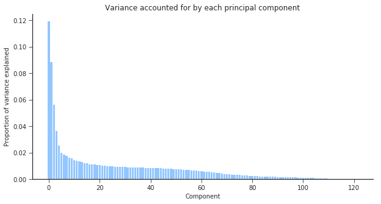

```python
# Investigate the variance accounted for by each principal component.
fig = plt.figure(figsize=(10,5))
plt.bar(range(len(pca.explained_variance_ratio_)), pca.explained_variance_ratio_)
plt.xlabel("Component")
plt.ylabel("Proportion of variance explained")
plt.title("Variance accounted for by each principal component")
sns.despine()
plt.show()
```

```python
threshold = 0.80
y1 = np.cumsum(pca.explained_variance_ratio_)

number_of_components = int(np.argwhere(y1>=threshold)[1])
print("We retain {} components for analysis because they explain {}% of the variance in the data."
      .format(number_of_components, int(threshold*100)))
```

```
We retain 50 components for analysis because they explain 80% of the variance in the data.
```

```python
# Re-apply PCA to the data while selecting for number of components to retain.
pca = PCA(n_components=number_of_components)
azdias = pca.fit_transform(standard_scaled_azdias)
```

```python
azdias = pd.DataFrame(azdias)
display(azdias)
```

[output not shown]

623209 rows × 50 columns

### Discussion 2.2: Perform Dimensionality Reduction

I retained 50 components for the rest of the analysis, as they explain 80% of the variance in the data.

### Step 2.3: Interpret Principal Components

Now that we have our transformed principal components, it's a nice idea to check out the weight of each variable on the first few components to see if they can be interpreted in some fashion.

As a reminder, each principal component is a unit vector that points in the direction of highest variance (after accounting for the variance captured by earlier principal components). The further a weight is from zero, the more the principal component is in the direction of the corresponding feature. If two features have large weights of the same sign (both positive or both negative), then increases in one tend expect to be associated with increases in the other. To contrast, features with different signs can be expected to show a negative correlation: increases in one variable should result in a decrease in the other.

- To investigate the features, you should map each weight to their corresponding feature name, then sort the features according to weight. The most interesting features for each principal component, then, will be those at the beginning and end of the sorted list. Use the data dictionary document to help you understand these most prominent features, their relationships, and what a positive or negative value on the principal component might indicate.
- You should investigate and interpret feature associations from the first three principal components in this substep. To help facilitate this, you should write a function that you can call at any time to print the sorted list of feature weights, for the *i*-th principal component. This might come in handy in the next step of the project, when you interpret the tendencies of the discovered clusters.

```python
# HINT: Try defining a function here or in a new cell that you can reuse in the
# other cells.

def pca_results(pca, i):
    df = pd.DataFrame(pca.components_, columns=list(standard_scaled_azdias.columns))
    component = df.iloc[i].sort_values()
    return component
```

```python
# Map weights for the first principal component to corresponding feature names
# and then print the linked values, sorted by weight.

print(pca_results(pca, 0))
```

```
MOBI_REGIO              -0.205030
FINANZ_MINIMALIST       -0.200890
KBA05_ANTG1             -0.192513
PLZ8_ANTG1              -0.187695
KBA05_GBZ               -0.181714
PLZ8_GBZ                -0.141685
KONSUMNAEHE             -0.135146
INNENSTADT              -0.130393
ALTERSKATEGORIE_GROB    -0.122531
LP_STATUS_GROB_5.0      -0.119299
FINANZ_VORSORGER        -0.116442
CAMEO_INTL_life_stage   -0.115419
PJ_movement             -0.108074
GREEN_AVANTGARDE        -0.108074
LP_STATUS_GROB_4.0      -0.103928
GEBAEUDETYP_RASTER      -0.097492
BALLRAUM                -0.097277
FINANZTYP_2             -0.093315
SEMIO_LUST              -0.089093
ZABEOTYP_1              -0.088018
CAMEO_DEUG_2015_2       -0.083704
SEMIO_ERL               -0.081918
ANZ_PERSONEN            -0.075779
CAMEO_DEUG_2015_4       -0.071841
NATIONALITAET_KZ_1.0    -0.070418
KBA13_ANZAHL_PKW        -0.067711
CAMEO_DEUG_2015_3       -0.063828
WOHNDAUER_2008          -0.062804
CJT_GESAMTTYP_2.0       -0.060094
LP_FAMILIE_GROB_5.0     -0.058975
                           ...
LP_FAMILIE_GROB_1.0      0.076199
FINANZ_ANLEGER           0.078251
SEMIO_MAT                0.079580
FINANZ_UNAUFFAELLIGER    0.080135
CAMEO_DEUG_2015_8        0.088604
ZABEOTYP_5               0.089969
SEMIO_RAT                0.093894
SEMIO_TRADV              0.099561
RELAT_AB                 0.105370
SEMIO_REL                0.106094
PJ_decade                0.108917
SEMIO_PFLICHT            0.111255
CAMEO_DEUG_2015_9        0.112108
ANZ_HAUSHALTE_AKTIV      0.114389
KBA05_ANTG3              0.115454
ARBEIT                   0.115722
PLZ8_ANTG2               0.121359
PLZ8_BAUMAX_buildings    0.122328
FINANZTYP_1              0.124767
KBA05_ANTG4              0.128161
FINANZ_HAUSBAUER         0.132627
FINANZ_SPARER            0.144403
EWDICHTE                 0.153412
ORTSGR_KLS9              0.156141
HH_EINKOMMEN_SCORE       0.178695
CAMEO_INTL_wealth        0.178743
PLZ8_BAUMAX              0.180703
PLZ8_ANTG4               0.180994
PLZ8_ANTG3               0.184657
LP_STATUS_GROB_1.0       0.192255
Name: 0, Length: 122, dtype: float64
```

```python
# Map weights for the second principal component to corresponding feature names
# and then print the linked values, sorted by weight.
print(pca_results(pca, 1))
```

```
PJ_decade               -0.225571
SEMIO_REL               -0.219160
FINANZ_SPARER           -0.207081
FINANZ_UNAUFFAELLIGER   -0.206628
SEMIO_PFLICHT           -0.205414
SEMIO_TRADV             -0.202158
FINANZ_ANLEGER          -0.186241
SEMIO_KULT              -0.173851
ONLINE_AFFINITAET       -0.162098
SEMIO_RAT               -0.155431
SEMIO_FAM               -0.137490
SEMIO_MAT               -0.123364
FINANZTYP_1             -0.111645
ZABEOTYP_4              -0.102365
PLZ8_ANTG1              -0.100804
MOBI_REGIO              -0.097903
KBA05_GBZ               -0.093907
FINANZTYP_4             -0.093850
KBA05_ANTG1             -0.090402
FINANZTYP_3             -0.081514
ZABEOTYP_1              -0.081469
PLZ8_GBZ                -0.080097
ZABEOTYP_5              -0.078437
INNENSTADT              -0.074603
ANZ_PERSONEN            -0.071938
SEMIO_SOZ               -0.071923
KONSUMNAEHE             -0.070731
GFK_URLAUBERTYP_9.0     -0.068473
SHOPPER_TYP_0.0         -0.064585
LP_FAMILIE_GROB_4.0     -0.064485
                           ...
HH_EINKOMMEN_SCORE       0.058977
PLZ8_BAUMAX_buildings    0.061120
ANZ_HAUSHALTE_AKTIV      0.062970
RELAT_AB                 0.063905
FINANZTYP_6              0.064052
PLZ8_ANTG2               0.065009
LP_FAMILIE_GROB_1.0      0.066572
CJT_GESAMTTYP_1.0        0.066631
ARBEIT                   0.070039
KBA05_ANTG4              0.070808
FINANZTYP_2              0.074178
SHOPPER_TYP_3.0          0.075692
SEMIO_KAEM               0.078417
CAMEO_INTL_wealth        0.083444
EWDICHTE                 0.090028
ORTSGR_KLS9              0.090338
FINANZTYP_5              0.090400
SEMIO_KRIT               0.092927
PLZ8_BAUMAX              0.094713
PLZ8_ANTG4               0.097051
CJT_GESAMTTYP_2.0        0.099712
PLZ8_ANTG3               0.100170
FINANZ_HAUSBAUER         0.112807
W_KEIT_KIND_HH           0.124273
RETOURTYP_BK_S           0.154094
SEMIO_LUST               0.155070
SEMIO_ERL                0.189141
ZABEOTYP_3               0.201419
FINANZ_VORSORGER         0.202995
ALTERSKATEGORIE_GROB     0.224450
Name: 1, Length: 122, dtype: float64
```

```python
# Map weights for the third principal component to corresponding feature names
# and then print the linked values, sorted by weight.

print(pca_results(pca, 2))
```

```
ANREDE_KZ               -0.348743
SEMIO_KAEM              -0.321968
SEMIO_DOM               -0.292326
SEMIO_KRIT              -0.263789
SEMIO_ERL               -0.191421
SEMIO_RAT               -0.174965
FINANZ_ANLEGER          -0.161754
SHOPPER_TYP_2.0         -0.111794
FINANZTYP_1             -0.108080
PJ_decade               -0.071820
ZABEOTYP_4              -0.070867
FINANZ_SPARER           -0.069065
FINANZ_UNAUFFAELLIGER   -0.059575
FINANZ_HAUSBAUER        -0.054848
LP_FAMILIE_GROB_3.0     -0.052371
INNENSTADT              -0.051030
PLZ8_ANTG1              -0.047103
SHOPPER_TYP_3.0         -0.046492
KONSUMNAEHE             -0.045058
BALLRAUM                -0.043886
SEMIO_TRADV             -0.043679
SEMIO_PFLICHT           -0.040560
GEBAEUDETYP_RASTER      -0.037507
PLZ8_GBZ                -0.036847
HH_EINKOMMEN_SCORE      -0.036822
ONLINE_AFFINITAET       -0.034071
NATIONALITAET_KZ_3.0    -0.034066
ZABEOTYP_5              -0.034020
KKK                     -0.032797
GFK_URLAUBERTYP_9.0     -0.029967
                           ...
ARBEIT                   0.030529
RELAT_AB                 0.030868
PLZ8_ANTG2               0.031795
GFK_URLAUBERTYP_4.0      0.033605
ALTERSKATEGORIE_GROB     0.040406
SHOPPER_TYP_1.0          0.042981
LP_STATUS_GROB_5.0       0.043725
SEMIO_LUST               0.045057
PLZ8_BAUMAX_buildings    0.045517
PLZ8_ANTG3               0.047323
PLZ8_ANTG4               0.049165
ZABEOTYP_6               0.051043
PLZ8_BAUMAX              0.053534
ORTSGR_KLS9              0.055301
EWDICHTE                 0.055983
GREEN_AVANTGARDE         0.063860
PJ_movement              0.063860
FINANZ_VORSORGER         0.065191
SEMIO_MAT                0.070779
W_KEIT_KIND_HH           0.081003
RETOURTYP_BK_S           0.092834
SEMIO_REL                0.105647
ZABEOTYP_1               0.114266
SHOPPER_TYP_0.0          0.130697
FINANZ_MINIMALIST        0.137673
FINANZTYP_5              0.141130
SEMIO_KULT               0.239633
SEMIO_FAM                0.255548
SEMIO_SOZ                0.256747
SEMIO_VERT               0.327219
Name: 2, Length: 122, dtype: float64
```

### Discussion 2.3: Interpret Principal Components

- Interpretation of the principal components is based on finding which variables are most strongly correlated with each component, i.e., which of these numbers are large in magnitude, the farthest from zero in either direction. Which numbers we consider to be large or small is of course is a subjective decision. You need to determine at what level the correlation is of importance.
- The further a weight is from zero, the more the principal component is in the direction of the corresponding feature. If two features have large weights of the same sign (both positive or both negative), then increases in one tend expect to be associated with increases in the other. To contrast, features with different signs can be expected to show a negative correlation: increases in one variable should result in a decrease in the other.

##### First Principal Component :

This component is negatively correlated with the features associated with

a) movement patterns (high values indicating low movement) b) low financial interest typology (high values indicating a low dimension) c) number of 1-2 family houses in the KBA05 microcell (high values here indicate a high number of such houses in the microcell).

##### Second Principal Component:

This component is negatively correlated with the features indicating

a) decade of a person's youth (with high values indicating those whose youth was in the 80s and 90s - millenials) b) religious affinity (with high values here indicating low religious affinity) c) being a money saver (high values here indicating a low tendency).

It is positively correlated with the features representing a) age (with high values indicating older people) b) a financial typology of "be-prepared" (high values indicating a low interest) c) affinity for events (with high values indicating a low affinity for events) d) energy consumption typology (with high values tending to indicate indifference).

This component can be viewed as a measure of a person's stage in life and worldview. A positive value here indicates an older, more religious, dutiful person, who has a low affinity for events and is generally unprepared for major expenditures.

##### Third Principal Component

This component is negatively correlated with a) Gender (Higher values indicate females) b) combative attitude c) being dominant-minded ( with higher values indicating low combativeness and dominant-mindedness respectively)

It is positively correlated with features representing a) dreamfulness b) social-mindedness c) family-mindedness.

For all three of these features, high values indicate low affinities.

This component can therefore be viewed as a measure of a person's gender and worldview.

- A positive value here would indicate a male who is combative and dominant-minded
- A negative value would indicate a female who is dreamful, family-minded and socially-minded.

## Step 3: Clustering

### Step 3.1: Apply Clustering to General Population

You've assessed and cleaned the demographics data, then scaled and transformed them. Now, it's time to see how the data clusters in the principal components space. In this substep, you will apply k-means clustering to the dataset and use the average within-cluster distances from each point to their assigned cluster's centroid to decide on a number of clusters to keep.

- Use sklearn's KMeans class to perform k-means clustering on the PCA-transformed data.
- Then, compute the average difference from each point to its assigned cluster's center. **Hint**: The KMeans object's `.score()` method might be useful here, but note that in sklearn, scores tend to be defined so that larger is better. Try applying it to a small, toy dataset, or use an internet search to help your understanding.
- Perform the above two steps for a number of different cluster counts. You can then see how the average distance decreases with an increasing number of clusters. However, each additional cluster provides a smaller net benefit. Use this fact to select a final number of clusters in which to group the data. **Warning**: because of the large size of the dataset, it can take a long time for the algorithm to resolve. The more clusters to fit, the longer the algorithm will take. You should test for cluster counts through at least 10 clusters to get the full picture, but you shouldn't need to test for a number of clusters above about 30.
- Once you've selected a final number of clusters to use, re-fit a KMeans instance to perform the clustering operation. Make sure that you also obtain the cluster assignments for the general demographics data, since you'll be using them in the final Step 3.3.

```python
from sklearn.cluster import KMeans

def get_kmeans_score(dataset, cluster):
    kmeans = KMeans(n_clusters= cluster)
    model = kmeans.fit(dataset)
    score = np.abs(model.score(dataset))
    return score
```

```python
# Investigate the change in within-cluster distance across number of clusters.
# HINT: Use matplotlib's plot function to visualize this relationship.

scores = []
clusters = list(range(10,20))
i = 0

for cluster in clusters:
    scores.append(get_kmeans_score(azdias, cluster))
    print ("Number of Clusters considered : {}".format(cluster))
    print ("Sum of Squared Errror : {}".format(scores[i]))
    i = i +1
```

```
Number of Clusters considered : 10
Sum of Squared Errror : 42956335.9399646
Number of Clusters considered : 11
Sum of Squared Errror : 42509806.80699849
Number of Clusters considered : 12
Sum of Squared Errror : 42136865.92117679
Number of Clusters considered : 13
Sum of Squared Errror : 41754758.33798098
Number of Clusters considered : 14
Sum of Squared Errror : 41434622.55235471
Number of Clusters considered : 15
Sum of Squared Errror : 40998575.11531718
Number of Clusters considered : 16
Sum of Squared Errror : 40573794.78084241
Number of Clusters considered : 17
Sum of Squared Errror : 40297952.72481347
Number of Clusters considered : 18
Sum of Squared Errror : 39989481.44918018
Number of Clusters considered : 19
Sum of Squared Errror : 39761506.15718996
```

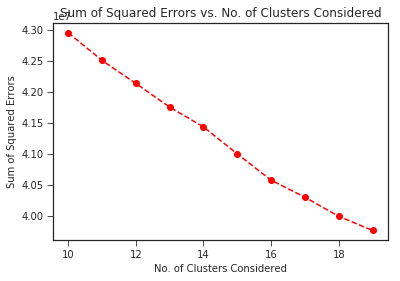

```python
# Plot the SSE vs No. of Clusters considered graph to find the elbow.
plt.plot(clusters, scores, linestyle='--', marker='o', color='r');
plt.xlabel('No. of Clusters Considered');
plt.ylabel('Sum of Squared Errors');
plt.title('Sum of Squared Errors vs. No. of Clusters Considered');
```

```python
# Re-fit the k-means model with the selected number of clusters and obtain
# cluster predictions for the general population demographics data.
kmeans = KMeans(n_clusters = 16)
azdias_clusters = kmeans.fit_predict(azdias);
```

### Discussion 3.1: Apply Clustering to General Population

From the graph above, there is an 'elbow' estimated at 16 clusters, and so I decided to segment the population into 16 clusters.

### Step 3.2: Apply All Steps to the Customer Data

Now that you have clusters and cluster centers for the general population, it's time to see how the customer data maps on to those clusters. Take care to not confuse this for re-fitting all of the models to the customer data. Instead, you're going to use the fits from the general population to clean, transform, and cluster the customer data. In the last step of the project, you will interpret how the general population fits apply to the customer data.

- Don't forget when loading in the customers data, that it is semicolon (`;`) delimited.
- Apply the same feature wrangling, selection, and engineering steps to the customer demographics using the `clean_data()` function you created earlier. (You can assume that the customer demographics data has similar meaning behind missing data patterns as the general demographics data.)
- Use the sklearn objects from the general demographics data, and apply their transformations to the customers data. That is, you should not be using a `.fit()` or `.fit_transform()` method to re-fit the old objects, nor should you be creating new sklearn objects! Carry the data through the feature scaling, PCA, and clustering steps, obtaining cluster assignments for all of the data in the customer demographics data.

```python
# Load in the customer demographics data.
customers = pd.read_csv("Udacity_CUSTOMERS_Subset.csv", sep=";")
```

```python
customers = clean_data(customers)
customers.head()
```

|  | ALTERSKATEGORIE_GROB | ANREDE_KZ | FINANZ_MINIMALIST | FINANZ_SPARER | FINANZ_VORSORGER | FINANZ_ANLEGER | FINANZ_UNAUFFAELLIGER | FINANZ_HAUSBAUER | GREEN_AVANTGARDE | HEALTH_TYP | ... | CAMEO_DEUG_2015_5 | CAMEO_DEUG_2015_6 | CAMEO_DEUG_2015_7 | CAMEO_DEUG_2015_8 | CAMEO_DEUG_2015_9 | PJ_decade | PJ_movement | CAMEO_INTL_wealth | CAMEO_INTL_life_stage | PLZ8_BAUMAX_buildings |
| --- | --- | --- | --- | --- | --- | --- | --- | --- | --- | --- | --- | --- | --- | --- | --- | --- | --- | --- | --- | --- | --- |
| 0 | 4.0 | 1 | 5 | 1 | 5 | 1 | 2 | 2 | 1 | 1.0 | ... | 0 | 0 | 0 | 0 | 0 | 2.0 | 2.0 | 1 | 3 | 1.0 |
| 2 | 4.0 | 2 | 5 | 1 | 5 | 1 | 4 | 4 | 1 | 2.0 | ... | 1 | 0 | 0 | 0 | 0 | 2.0 | 2.0 | 3 | 4 | 1.0 |
| 4 | 3.0 | 1 | 3 | 1 | 4 | 4 | 5 | 2 | 0 | 3.0 | ... | 0 | 0 | 1 | 0 | 0 | 4.0 | 1.0 | 4 | 1 | 1.0 |
| 5 | 3.0 | 1 | 5 | 1 | 5 | 1 | 2 | 3 | 1 | 3.0 | ... | 1 | 0 | 0 | 0 | 0 | 2.0 | 2.0 | 3 | 4 | 1.0 |
| 6 | 4.0 | 1 | 5 | 1 | 5 | 1 | 1 | 2 | 1 | 2.0 | ... | 0 | 0 | 0 | 0 | 0 | 2.0 | 2.0 | 2 | 3 | 1.0 |

5 rows × 122 columns

```python
# Apply preprocessing, feature transformation, and clustering from the general
# demographics onto the customer data, obtaining cluster predictions for the
# customer demographics data.
standard_scaled_customers = scaler.transform(customers)
standard_scaled_customers = pd.DataFrame(standard_scaled_customers, columns=list(customers))

customer_df = pd.DataFrame(pca.transform(standard_scaled_customers))


customer_clusters = kmeans.predict(customer_df);
```

```python
display(customer_clusters)
```

```
array([12, 13,  1, ..., 12, 13,  7], dtype=int32)
```

### Step 3.3: Compare Customer Data to Demographics Data

At this point, you have clustered data based on demographics of the general population of Germany, and seen how the customer data for a mail-order sales company maps onto those demographic clusters. In this final substep, you will compare the two cluster distributions to see where the strongest customer base for the company is.

Consider the proportion of persons in each cluster for the general population, and the proportions for the customers. If we think the company's customer base to be universal, then the cluster assignment proportions should be fairly similar between the two. If there are only particular segments of the population that are interested in the company's products, then we should see a mismatch from one to the other. If there is a higher proportion of persons in a cluster for the customer data compared to the general population (e.g. 5% of persons are assigned to a cluster for the general population, but 15% of the customer data is closest to that cluster's centroid) then that suggests the people in that cluster to be a target audience for the company. On the other hand, the proportion of the data in a cluster being larger in the general population than the customer data (e.g. only 2% of customers closest to a population centroid that captures 6% of the data) suggests that group of persons to be outside of the target demographics.

Take a look at the following points in this step:

- Compute the proportion of data points in each cluster for the general population and the customer data. Visualizations will be useful here: both for the individual dataset proportions, but also to visualize the ratios in cluster representation between groups. Seaborn's [`countplot()`](https://seaborn.pydata.org/generated/seaborn.countplot.html) or [`barplot()`](https://seaborn.pydata.org/generated/seaborn.barplot.html) function could be handy.
  - Recall the analysis you performed in step 1.1.3 of the project, where you separated out certain data points from the dataset if they had more than a specified threshold of missing values. If you found that this group was qualitatively different from the main bulk of the data, you should treat this as an additional data cluster in this analysis. Make sure that you account for the number of data points in this subset, for both the general population and customer datasets, when making your computations!
- Which cluster or clusters are overrepresented in the customer dataset compared to the general population? Select at least one such cluster and infer what kind of people might be represented by that cluster. Use the principal component interpretations from step 2.3 or look at additional components to help you make this inference. Alternatively, you can use the `.inverse_transform()` method of the PCA and StandardScaler objects to transform centroids back to the original data space and interpret the retrieved values directly.
- Perform a similar investigation for the underrepresented clusters. Which cluster or clusters are underrepresented in the customer dataset compared to the general population, and what kinds of people are typified by these clusters?

```python
# Compare the proportion of data in each cluster for the customer data to the
# proportion of data in each cluster for the general population.
K = 16
n_general_population = []
n_customer = []
for i in range(K):
    n_general_population.append(np.argwhere(azdias_clusters==i).shape[0]/azdias_clusters.shape[0])
    n_customer.append(np.argwhere(customer_clusters==i).shape[0]/customer_clusters.shape[0])
```

```python
label_counts = pd.DataFrame({'General Population': n_general_population})
label_counts['Customers'] = pd.Series(n_customer)
label_counts['Clusters'] = pd.Series(list(range(K)))
```

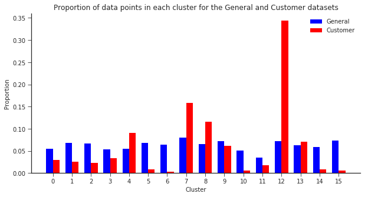

```python
# Plot the graphs
N = K
customer_props = label_counts['Customers']
general_props = label_counts['General Population']

ind = np.arange(N)
width = 0.35

plt.figure(figsize=(10,5))
plt.bar(ind, general_props, width, color='blue', label='General')
plt.bar(ind + width, customer_props, width, color='red',
    label='Customer')

plt.ylabel('Proportion')
plt.xlabel('Cluster')
plt.title('Proportion of data points in each cluster for the General and Customer datasets')

plt.xticks(ind + width / 2, range(N))
plt.legend(loc='best')
sns.despine()
plt.show()
```

```python
customer_df.loc[customer_df['labels'] == 12]
```

[output not shown]

39703 rows × 51 columns